# FPROSoC in Chisel

Projekt pri predmetu Digitalno Načrtovanje

Samo Golež

4. 2. 2025

# Chisel

[interactive chart not shown]

## Hardware generation

- scripting languages were used to generate VHDL/Verilog (string based)
- SystemVerilog offers some generational constructs (`#(parameter N=4)`, `generate`)

## Hardware construction language

- Scala classes (using various parameters and generics) are hardware generators
- advance generation using loops and higher order functions

# Chisel to Verilog

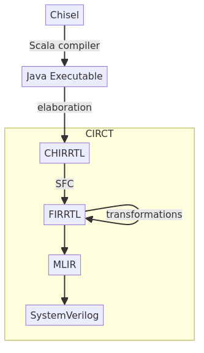

## Elaboration

```scala
// The body of a Scala class is the default constructor
// MyModule's default constructor has a single Int argument
// Superclass Module is a chisel3 Class that begins construction of a hardware module
// Implicit clock and reset inputs are added by the Module constructor
class MyModule(width: Int) extends Module {
  // io is a required field for subclasses of Module
  // new Bundle creates an instance of an anonymous subclass of Chisel's Bundle (like a struct)
  // When executing the function IO(...), Chisel adds ports to the Module based on the Bundle object
  val io = IO(new Bundle {
    val in = Input(UInt(width.W)) // Input port with width defined by parameter
    val out = Output(UInt()) // Output port with width inferred by Chisel
  })

  // A Scala println that will print at elaboration time each time this Module is instantiated
  // This does NOT create a node in the Module AST
  println(s"Constructing MyModule with width $width")

  // Adds a register declaration node to the Module AST
  // This counter register resets to the value of input port io.in
  // The implicit clock and reset inputs feed into this node
  val counter = RegInit(io.in)

  // Adds an addition node to the hardware AST with operands counter and 1
  val inc = counter + 1.U // + is overloaded, this is actually a Chisel function call

  // Connects the output of the addition node to the "next" value of counter
  counter := inc

  // Adds a printf node to the Module AST that will print at simulation time
  // The value of counter feeds into this node
  printf("counter = %d\n", counter)
}
```

# Design flow in Chisel

## Chisel Tree

```
.
├── build.sbt
├── src/
|   ├── main/
|   |   ├── resources/
|   |   |   └ *.sv
|   |   └── scala/cpro/
|   |       └ Top.scala
|   └── test/scala/cpro/
|       └ *.scala
└── target_sv/
    └ *.sv
```

## `BlackBox`

```scala
/*
module Top(
  input         clock,
                reset,
  input  [15:0] sw,
  output [15:0] led,
  output [7:0]  anode_assert,
  output [6:0]  segs
);
*/
class Top extends BlackBox with HasBlackBoxResource {
  val io = IO(new Bundle {
    // in blackbox we need to explicitly provide clock&reset
    val clock = Input(Clock())
    val reset = Input(Reset())
    val sw = Input(UInt(16.W))
    val led = Output(UInt(16.W))
    val anode_assert = Output(UInt(8.W))
    val segs = Output(UInt(7.W))
  })
  // will copy resource files into target_sv
  addResource("/top.sv")
  addResource("/mcs_bridge.sv")
  addResource("/mmio_controller.sv")
  addResource("/mmio_cores.sv")
  addResource("/mmio_subsystem.sv")
}
```

## `ChiselStage`

```scala
object Top extends App {
  ChiselStage.emitSystemVerilogFile(
    new Top,
    Array("--split-verilog", "--target-dir", "target_sv/"),
    firtoolOpts = Array("-disable-all-randomization", "-strip-debug-info") // make verilog human readable
  )
}
```

## Incremental rewrite

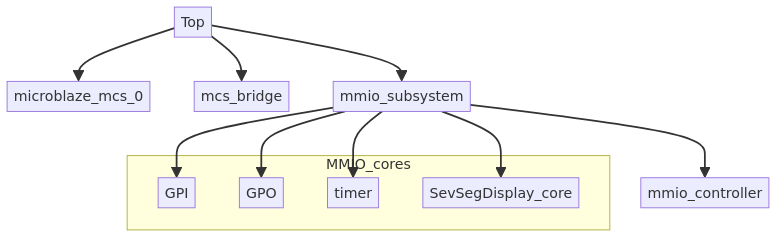

# Verilog -> Chisel

## `Data`

[figure not shown]

<sup>Data can be represented as a bit vector in a hardware design</sup>

## `Bool`

`Bool()` represents single bit that can be `true.B` or `false.B`. Chisel does not have representation of Z or X states.

## `UInt`

`value.U(width.W)`

```scala
0xA0.U(16.W) // this can be problematic if we overflow Scala integer
"hA0".U(16.W) // so string literals are preferred
```

## slices

| Verilog | Chisel |
| --- | --- |
| `a[15]` | `a(15)` |
| `a[32:16]` | `a(32,16)` |

## slice assignment

Chisel does not support slice/subword assignment, but that limitation can be bypassed by conCATenation or by transmuting to `Vec` or `Bundle`

```scala
val data = 0.U(8.W)
val ones = chisel3.util.Fill(4, 1.U) // 0b1111
// {4{1}}
val data2 = chisel3.util.Cat(data, ones).U(8.W) // 0b0000_1111
// {data,ones}
val data22 = chisel3.util.Cat(data(7,4), ones) // 0b0000_1111
```

## `Vec`

`Vec`tors are like arrays. They have fixed size of same type/size elements. This restriction is relaxed in `MixedVec`

```scala
val a = Vec(4, Bool())
// with default options this becomes:
/*
logic a_0;
logic a_1;
logic a_2;
logic a_3;
*/
```

## `Bundle`

Are like `struct` in C, they group together several named fields. This is mostly used to group ports (module inputs/outputs) into Bundles.

```scala
val b = new Bundle({
  val a = Bool()
  val b = Bool()
  val c = Bool()
})
/*
logic b_a
logic b_b
logic b_c
*/
```

## `Module` definition

```
module M
#(
    parameter ARG = 32'hc000_0000
)
(
    input logic clock,
    input logic reset,

    input logic inn,
    input logic [31:0] inn_,
    input logic [63:0][31:0] inn_arr, // Packed array
    // Chisel does not support unpacked arrays: [31:0] inn_arr [63:0]

    output logic out,
    output logic [31:0] out_,
    output logic [63:0][31:0] out_arr,
);
//...
endmodule
```

```scala
// whole class definition is actually class constructor
class M(ARG: Long = 0xc000_0000L) extends Module {
    require(ARG > 0) // assert assumptions
    /*
    // Module has implicit clock&reset signals
    val clock = Input(Clock())
    val reset = Input(Reset())
    */

    // all IO connections are typically joined in IO Bundle
    val io = IO(new Bundle {
        val inn = Input(Bool())
        val inn_ = Input(UInt(32.W/*idth*/)) // common pitfall: [31:0] has width of 32 not 31
        val inn_arr = Input(Vec(64, UInt(32.W)))
        // To consider vectors as packed arrays instead of scalarized inputs
        // the following options are needed to be passed to firtool:
        // -preserve-aggregate=all -scalarize-public-modules=false -scalarize-ext-modules=false

        val out = Output(Bool())
        val out_ = Output(UInt(32.W))
        val out_arr = Output(Vec(64, UInt(32.W)))
    })
    // ...
}
```

## Module instantiation

```
M m (
    .inn     (_inn),
    .inn_    (_inn_),
    .inn_arr (_inn_arr),
    .out     (_out),
    .out_    (_out_),
    .out_arr (_out_arr),
);
```

```scala
val m = Module(new M)
/*
// implicit clock&reset signals are automatically connected
m.clock <> clock
m.reset <> reset
*/
m.io.inn <> _inn
m.io.inn_ <> _inn_
m.io.inn_arr <> _inn_arr
m.io.out <> _out
m.io.out_ <> _out_
m.io.out_arr <> _out_arr
// or if we use :=
m.io.inn := _inn
m.io.inn_ := _inn_
m.io.inn_arr := _inn_arr
_out := m.io.out
_out_ := m.io.out_
_out_arr := m.io.out_arr
// if any connections are missing we get elaboration error
```

## `=`,`:=`,`<>`

- `=` is Scala assignment (evaluated at elaboration time)
- `sink := source` is Chisel (mono-directional) assignment (`assign =`, `<=`)
- `<>` is Chisel bi-directional connection operator (`assign =`)

## “Variables”

| Verilog | Chisel |
| --- | --- |
| `logic a;` | / |
| `wire a;` | `val a = Wire(/*type*/)` |
| `reg a;` | `val a = Reg(/*type*/)` |
|  | `val a = RegInit(reset_value)` |
|  | `val a = RegNext(next_value, reset_value)` |

## `RegInit`

```scala
val r = RegInit(0.U(32.W)) // NOTE: implicit clock&reset
// Chisel will automatically put reg assignments into always_ff block
// that is by default run on positive edge
r := 1.U
r := 2.U // last assignments wins
```

## `RegInit` manually (using `when`)

```scala
val r = Reg(UInt(32.W)) // NOTE: implicit clock
r := 1.U
// when cannot use Scala's if as those are evaluated at elaboration
//(are equal to Verilog's `generate if`)
when(reset) { // will add special HW AST that will emit `if` in Verilog
  r := 0.U
}.elsewhen(false.B) {
  // never
}.otherwise {
  r := 2.U
}
```

## in Verilog

```
reg [31:0] r;
always @(posedge clock) begin
  if (reset)
    r <= 0;
  else
    r <= 2;
end
```

## Switch

```
case (digit)
  4'b0000: segs = 7'b1000000; // 0
  4'b0001: segs = 7'b1111001; // 1
  4'b0010: segs = 7'b0100100; // 2
  4'b0011: segs = 7'b0110000; // 3
  4'b0100: segs = 7'b0011001; // 4
  4'b0101: segs = 7'b0010010; // 5
  4'b0110: segs = 7'b0000010; // 6
  4'b0111: segs = 7'b1111000; // 7
  4'b1000: segs = 7'b0000000; // 8
  4'b1001: segs = 7'b0010000; // 9
  4'b1010: segs = 7'b0001000; // A
  4'b1011: segs = 7'b0000011; // b
  4'b1100: segs = 7'b1000110; // C
  4'b1101: segs = 7'b0100001; // d
  4'b1110: segs = 7'b0000110; // E
  4'b1111: segs = 7'b0001110; // F
  default: segs = 7'b1111111; // off
endcase
```

```scala
io.segs := "b11111111".U // default
switch(digit) {
  is("b0000".U) { io.segs := "b1000000".U } // 0
  is("b0001".U) { io.segs := "b1111001".U } // 1
  is("b0010".U) { io.segs := "b0100100".U } // 2
  is("b0011".U) { io.segs := "b0110000".U } // 3
  is("b0100".U) { io.segs := "b0011001".U } // 4
  is("b0101".U) { io.segs := "b0010010".U } // 5
  is("b0110".U) { io.segs := "b0000010".U } // 6
  is("b0111".U) { io.segs := "b1111000".U } // 7
  is("b1000".U) { io.segs := "b0000000".U } // 8
  is("b1001".U) { io.segs := "b0010000".U } // 9
  is("b1010".U) { io.segs := "b0001000".U } // A
  is("b1011".U) { io.segs := "b0000011".U } // b
  is("b1100".U) { io.segs := "b1000110".U } // C
  is("b1101".U) { io.segs := "b0100001".U } // d
  is("b1110".U) { io.segs := "b0000110".U } // E
  is("b1111".U) { io.segs := "b0001110".U } // F
}
```

# Testing

```
module tb_GPI;
    // Declare testbench signals
    logic clock;
    logic reset;
    logic [4:0] address;
    logic [31:0] rd_data;
    // ...

    // Instantiate the GPI module
    GPI dut (
        .clock(clock),
        .reset(reset),
        .address(address),
        .rd_data(rd_data),
        // ...
    );

    // Clock generation
    initial begin
        clock = 0;
        forever #5 clock = ~clock; // 100 MHz clock
    end

    // Test sequence
    initial begin
        // Initialize signals
        reset = 1;
        address = 5'b0;

        // Apply reset
        #10;
        reset = 0;

        #20;
        assert (rd_data == 0);

        $finish;
    end
endmodule
```

```scala
class GPISpec extends AnyFreeSpec with Matchers {
  "GPI should work" in {
    simulate(new GPI()) { dut =>
      // Initialize signals
      dut.reset.poke(true.B)
      dut.slot_io.address.poke(0.U)

      // Apply reset
      dut.clock.step(1)
      dut.reset.poke(false.B)

      dut.clock.step(2)
      dut.slot_io.rd_data.expect(0.U)
    }
  }
}
```

# Idiomatic Chisel

Verilog can be simply mapped to Chisel, but such Chisel code is not idiomatic/optimal

## `chisel3.util.Counter`

```scala
val (count: UInt, wrap: Bool) = Counter(0 until 40000, enabled, reset)
```

## More high level constructs

- `DecoupledIO` bundle with ready-valid interface
- `UIntToOH` & `OHToUInt` for one-hot encoding/decoding
- `Mux1H(sel: Seq[Bool], in: Seq[Data])`
- `ShiftRegister(in: Data, n: Int[, en: Bool]): Data`
- and much more in [Chisel cheatsheet](https://github.com/freechipsproject/chisel-cheatsheet/blob/master/chisel_cheatsheet-3.6.pdf)

## Directly connecting instances

In Chisel you can connect instances directly without intermediate wires:

```
-  val w = Wire(Bool())
val m1 = Module(M1())
-  m1.w <> w
val m2 = Module(M2())
-  m2.w <> w

+  m1.w <> m2.w
```

## Using `Bundle` for common ports

```scala
// FPro bus (consumer viewpoint)
class FPRO extends Bundle {
  val video_cs = Input(Bool())
  val mmio_cs = Input(Bool())
  val write = Input(Bool())
  val read = Input(Bool())
  val addr = Input(UInt(21.W))
  val wr_data = Input(UInt(32.W))
  val rd_data = Output(UInt(32.W))
}
```

## Reuse `Bundle`

```scala
// this module produces FPro signals
class mcs_bridge extends Module {
  val fp = Flipped(FPRO()) // flips Input <-> Output
  // ...
}

// this module passes down FPro signals
class mmio_subsystem extends Module {
  val fp = IO(FPRO())
  // ...
  val mmioController = Module(new mmio_controller())
  mmioController.fp <> fp // will connect all wires automatically
  // ...
}

// this module consumes FPro signals
class mmio_controller extends Module {
  val fp = IO(FPRO())
  // ...
}
```

## Using `trait` for interfaces

```scala
// define common interface for MMIO core
trait MMIO_core {
  val slot_io = IO(new Slot())
}

class GPI extends Module with MMIO_core {
  // implicit slot_io inherited from trait
  // val slot_io = IO(new Slot())

  // ...
}

class GPO extends Module with MMIO_core {
  // val slot_io = IO(new Slot())

  // ...
}
```

## for easier core additions

```scala
var slots: Array[MMIO_core] = Array()

// Instantiate the GPO (General Purpose Output)
val gpo = Module(new GPO())
gpo.io.data_out <> io.data_out
slots :+= gpo // append to array

// Instantiate the GPI (General Purpose Input)
val gpi = Module(new GPI())
gpi.io.data_in <> io.data_in
slots :+= gpi

// ...

require(slots.length < 64)
for ((core, i) <- slots.zipWithIndex) {
  core.slot_io.address <> reg_addr(i)
  core.slot_io.rd_data <> read_data(i)
  core.slot_io.wr_data <> write_data(i)
  core.slot_io.read <> read(i)
  core.slot_io.write <> write(i)
  core.slot_io.cs <> cs(i)
}
```

# More details in GitHub repo

https://github.com/schtrudl/cpro

# Discovered Vivaldo problems

- associate ELF does not work correctly if MCS is not in top module
- vivaldo does not check folder for new files so folder needs to be reimported
- sometimes changes are not detected (generate bitstream uses old files)

# Sources

- https://www.researchgate.net/publication/383664706_Hardware_Generators_with_Chisel
- https://circt.llvm.org/
- https://stackoverflow.com/questions/44548198/chisel-code-transformation
- https://chipyard.readthedocs.io/en/stable/Tools/index.html
- https://chipyard.readthedocs.io/en/stable/Customization/Firrtl-Transforms.html
- Schoeberl, M. (2019). Digital Design with Chisel. Kindle Direct Publishing
- https://github.com/freechipsproject/chisel-bootcamp
- https://en.wikipedia.org/wiki/SystemVerilog